# Term project

## References:

- Data Set:
  - https://www.kaggle.com/jvanelteren/boardgamegeek-reviews
    - Used for analysis and what we're looking to classify
- Existing work references:
  - https://www.kaggle.com/jvanelteren/exploring-the-13m-reviews-bgg-dataset
    - Goes over the contents of the data, not used here, but a good reference for understanding the contents.
- Code References:
  - pre-built sentiment analyzers:
    - https://github.com/cjhutto/vaderSentiment
      - used to determine polarity of reviews. The results are used to classify in a Naive Bayes classifier.
    - https://textblob.readthedocs.io/en/dev/api_reference.html#module-textblob.classifiers
      - used to make a quick to view custom classifier for given classification labels. typically for pos and neg classes, but can be extended to be used with a variety of classes if properly trained.
  - variety of NaiveBayes Classifiers:
    - https://scikit-learn.org/stable/modules/classes.html#module-sklearn.naive_bayes
      - documentation over Sci-kit Naive Bayes classifiers in practice.
    - https://datascience.stackexchange.com/questions/53100/training-textblob-with-16k-rows-of-labeled-data-wont-work-only-few-are-working
      - shows the WHY of the in efficiency of the TextBlob Classifier, and how to transition to a Sci-kit optimized classifier for our data set.
  - featrure extraction:
    - https://scikit-learn.org/stable/modules/generated/sklearn.feature_extraction.text.TfidfVectorizer.html
      - the end used feature extractor that can aid in optimizing our parsing of review input.

# Term Project

Joshua Tran, 1001296598, CSE-5334

## Objective:

The objective of this project is to produce a classifier that can take a look at a given review and produce a predicted rating. These reviews will be based off the datasets defined in the references for the 15 million reviews. Based off these criteria, I'll be implementing a NaiveBayes classifier along side with some pre-built sentiment analyzers to predict the rating of these reviews. However to accomplish this, a few things need to be noted about what has been done.

### pre-processing the data:

The data is vast and large, some of the data needs to pre-processed to ease training, and to get rid of non-helpful information. From the given set of reviews, to simplifiy processing we've made all the classifications into integers 0-10 for 11 total classifications. keeping the floating point representations left review classification values in the thousands of total classifications and seemed over complicated and undesirable. So this has been cleaned up.  
Additionally, I rid the data set from reviews that have no comment, because no comments doesn't help us predict actual comments.

## Libraries

```python
# base computation libraries
import numpy as np
import pandas as pd
from os import path
import matplotlib.pyplot as plt

# data splitting
from sklearn.model_selection import train_test_split

# feature extration
from sklearn.feature_extraction.text import TfidfVectorizer
from sklearn.pipeline import make_pipeline

# sentiment analyzers
from vaderSentiment.vaderSentiment import SentimentIntensityAnalyzer
from textblob import TextBlob

# naive bayes classifiers
from sklearn.naive_bayes import MultinomialNB
from textblob.classifiers import NaiveBayesClassifier

# classifier saving
import pickle

# needed for textblob custom:
# import nltk
#nltk.download('punkt')
```

### Grabbing the data

Simply, we grab the data here from the raw file, then round the ratings to be integer values.

```python
# path to reviews
ReviewPath = "C:\\Users\\j0sh7\\OneDrive\\Desktop\\Fall 2020\\Data mining\\term proj\\bgg-15m-reviews.csv"
df = pd.read_csv(ReviewPath).iloc[:, 1:]
df['rating']=df['rating'].round()
```

## Examining the given data:

Looks like with the given data we're given the following columns:

- A user
- A rating
- A comment
- An ID
- A name of a game

Here we can additionally see that there are a bunch of reviews that have "NaN" comments in value and wont help us.

```python
df
```

|  | user | rating | comment | ID | name |
| --- | --- | --- | --- | --- | --- |
| 0 | Torsten | 10.0 | NaN | 30549 | Pandemic |
| 1 | mitnachtKAUBO-I | 10.0 | Hands down my favorite new game of BGG CON 200... | 30549 | Pandemic |
| 2 | avlawn | 10.0 | I tend to either love or easily tire of co-op ... | 30549 | Pandemic |
| 3 | Mike Mayer | 10.0 | NaN | 30549 | Pandemic |
| 4 | Mease19 | 10.0 | This is an amazing co-op game. I play mostly ... | 30549 | Pandemic |
| ... | ... | ... | ... | ... | ... |
| 15823264 | Fafhrd65 | 8.0 | Turn based preview looks very promising. The g... | 281515 | Company of Heroes |
| 15823265 | PlatinumOh | 8.0 | KS | 281515 | Company of Heroes |
| 15823266 | BunkerBill | 7.0 | NaN | 281515 | Company of Heroes |
| 15823267 | Hattori Hanzo | 6.0 | NaN | 281515 | Company of Heroes |
| 15823268 | Richie2000 | 1.0 | NaN | 281515 | Company of Heroes |

15823269 rows × 5 columns

So lets remove those "NaN" comments

```python
df = df.dropna(subset = ['comment'])
df
```

|  | user | rating | comment | ID | name |
| --- | --- | --- | --- | --- | --- |
| 1 | mitnachtKAUBO-I | 10.0 | Hands down my favorite new game of BGG CON 200... | 30549 | Pandemic |
| 2 | avlawn | 10.0 | I tend to either love or easily tire of co-op ... | 30549 | Pandemic |
| 4 | Mease19 | 10.0 | This is an amazing co-op game. I play mostly ... | 30549 | Pandemic |
| 5 | cfarrell | 10.0 | Hey! I can finally rate this game I've been pl... | 30549 | Pandemic |
| 8 | gregd | 10.0 | Love it- great fun with my son. 2 plays so far... | 30549 | Pandemic |
| ... | ... | ... | ... | ... | ... |
| 15823242 | ChiefMe | 10.0 | KS Collector's Bundle with a friend of mine | 281515 | Company of Heroes |
| 15823247 | Mukaz | 10.0 | Belekokio Gerumo... | 281515 | Company of Heroes |
| 15823253 | jpaquila | 10.0 | Excelente!! lo mejor que probé. | 281515 | Company of Heroes |
| 15823264 | Fafhrd65 | 8.0 | Turn based preview looks very promising. The g... | 281515 | Company of Heroes |
| 15823265 | PlatinumOh | 8.0 | KS | 281515 | Company of Heroes |

2995023 rows × 5 columns

## Details of the data:

In the next two code blocks we can start to see what our data is looking like after we've cleaned it up a bit. First we can see that our count has drastically decreased to just below 3 million reviews that we can use. additionally the reviews average to just around a rating of 7.  
Additionally we can see in the chart below that the heavier concentration of review is towards 6 to 10 ratings.

```python
df.describe()
```

|  | rating | ID |
| --- | --- | --- |
| count | 2.995023e+06 | 2.995023e+06 |
| mean | 6.884759e+00 | 7.878041e+04 |
| std | 1.794539e+00 | 8.193324e+04 |
| min | 0.000000e+00 | 1.000000e+00 |
| 25% | 6.000000e+00 | 5.404000e+03 |
| 50% | 7.000000e+00 | 3.791900e+04 |
| 75% | 8.000000e+00 | 1.489490e+05 |
| max | 1.000000e+01 | 3.140400e+05 |

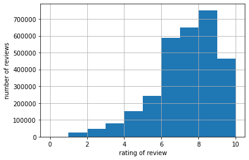

```python
df['rating'].hist(bins=10)
plt.xlabel('rating of review')
plt.ylabel('number of reviews')
plt.show()
```

## Taking a look at sentiment analysis: "Vader" Sentiment

```python
analyzer = SentimentIntensityAnalyzer()
print(df.iloc[1]['comment'])
sentiment_polarity_score_example = analyzer.polarity_scores(df.iloc[1]['comment'])
print("result of sentiment polarity scores:\n",sentiment_polarity_score_example)
```

```
I tend to either love or easily tire of co-op games.  Pandemic joins Knizia's LoTR as my favorite true co-op.  It edges LoTR out merely in time to set-up and play.  LoTR can be an undertaking to explain enough details so that players enjoy their first time through the game, while Pandemic is fast en…
result of sentiment polarity scores:
 {'neg': 0.0, 'neu': 0.786, 'pos': 0.214, 'compound': 0.9536}
```

## Applying sentiment analysis to our data set.

Below we have a method to be used to apply our vader sentiment analyzer to the data set. The idea here is to use the values generated by our analyzer to produce numerical values to use that will weight a Naive Bayes classifier to produce predictions on what the actual weight of the sentiment is.  
It is important to note that this processing takes a little bit of time, so i've generated a routine to check if the the processed sentiment has already been done, and if it has then we can just pull that data.

```python
def features(x):
    result = analyzer.polarity_scores(x)
    return pd.Series([result['neg'], result['neu'], result['pos'], result['compound']])
```

```python
polarity_score_path = 'C:\\Users\\j0sh7\\OneDrive\\Desktop\\Fall 2020\\Data mining\\term proj\\vader-processed.csv'
if(path.exists(polarity_score_path)):
    vader_processed_df = pd.read_csv(polarity_score_path)
# exporting data if it does not exists
else:
    df[['neg polarity','neu polarity','pos polarity','compound polarity']] = df['comment'].apply(features)
    df.to_csv(polarity_score_path,index=False)
    vader_processed_df = df
```

## Taking a look at the Vader processed data

```python
vader_processed_df
```

|  | user | rating | comment | ID | name | neg polarity | neu polarity | pos polarity | compound polarity |
| --- | --- | --- | --- | --- | --- | --- | --- | --- | --- |
| 0 | mitnachtKAUBO-I | 10.0 | Hands down my favorite new game of BGG CON 200... | 30549 | Pandemic | 0.061 | 0.797 | 0.142 | 0.7783 |
| 1 | avlawn | 10.0 | I tend to either love or easily tire of co-op ... | 30549 | Pandemic | 0.000 | 0.786 | 0.214 | 0.9536 |
| 2 | Mease19 | 10.0 | This is an amazing co-op game. I play mostly ... | 30549 | Pandemic | 0.075 | 0.626 | 0.299 | 0.9477 |
| 3 | cfarrell | 10.0 | Hey! I can finally rate this game I've been pl... | 30549 | Pandemic | 0.049 | 0.801 | 0.150 | 0.9734 |
| 4 | gregd | 10.0 | Love it- great fun with my son. 2 plays so far... | 30549 | Pandemic | 0.000 | 0.463 | 0.537 | 0.9312 |
| ... | ... | ... | ... | ... | ... | ... | ... | ... | ... |
| 2995018 | ChiefMe | 10.0 | KS Collector's Bundle with a friend of mine | 281515 | Company of Heroes | 0.000 | 0.686 | 0.314 | 0.4939 |
| 2995019 | Mukaz | 10.0 | Belekokio Gerumo... | 281515 | Company of Heroes | 0.000 | 1.000 | 0.000 | 0.0000 |
| 2995020 | jpaquila | 10.0 | Excelente!! lo mejor que probé. | 281515 | Company of Heroes | 0.000 | 1.000 | 0.000 | 0.0000 |
| 2995021 | Fafhrd65 | 8.0 | Turn based preview looks very promising. The g... | 281515 | Company of Heroes | 0.000 | 0.864 | 0.136 | 0.9013 |
| 2995022 | PlatinumOh | 8.0 | KS | 281515 | Company of Heroes | 0.000 | 1.000 | 0.000 | 0.0000 |

2995023 rows × 9 columns

```python
vader_processed_df.describe()
```

|  | rating | ID | neg polarity | neu polarity | pos polarity | compound polarity |
| --- | --- | --- | --- | --- | --- | --- |
| count | 2.995023e+06 | 2.995023e+06 | 2.995023e+06 | 2.995023e+06 | 2.995023e+06 | 2.995023e+06 |
| mean | 6.884759e+00 | 7.878041e+04 | 5.117841e-02 | 7.372406e-01 | 2.098811e-01 | 4.359725e-01 |
| std | 1.794539e+00 | 8.193324e+04 | 9.328355e-02 | 1.864656e-01 | 1.772728e-01 | 4.632109e-01 |
| min | 0.000000e+00 | 1.000000e+00 | 0.000000e+00 | 0.000000e+00 | 0.000000e+00 | -9.997000e-01 |
| 25% | 6.000000e+00 | 5.404000e+03 | 0.000000e+00 | 6.360000e-01 | 7.600000e-02 | 0.000000e+00 |
| 50% | 7.000000e+00 | 3.791900e+04 | 0.000000e+00 | 7.440000e-01 | 1.910000e-01 | 5.719000e-01 |
| 75% | 8.000000e+00 | 1.489490e+05 | 7.500000e-02 | 8.520000e-01 | 3.030000e-01 | 8.422000e-01 |
| max | 1.000000e+01 | 3.140400e+05 | 1.000000e+00 | 1.000000e+00 | 1.000000e+00 | 9.999000e-01 |

Here is a helper sub-routine to generate our accuracy of datasets.

```python
def findAccuracy(actual, predictions):
    return ( np.sum(actual == predictions)/len(actual) )
```

## Splitting the data

Now that we've applied our sentiment analysis to generate some features to determine a classification given a review. We need to seperate our data into a Training set and a Testing set. Below we generate a training set of 80% of the reviews and 20% of the reviews.

```python
X_train, X_test, y_train, y_test = train_test_split(np.stack(vader_processed_df[['neg polarity','neu polarity','pos polarity']].to_numpy()),vader_processed_df['rating'].values, test_size=0.2)
```

## Using the Naive Bayes classifier

Here we use our Naive bayes classifier, along with a variety of different smoothing paramters to adjust the alpha value (lap-lace smoothing value) four our classifier. However as the data shows below, the hyper parameter applied has no effect on this dataset. and seems to maintain it's accuracy.

```python
smoothingHyperParameter = [10.0, 5.0, 2.0, 1.0, 0.1, 0.01, 0.001, 0.0001, 0.00001]
for hyperParam in smoothingHyperParameter:
    MultinomialNB_clf = MultinomialNB(alpha=hyperParam)
    MultinomialNB_clf.fit(X_train, y_train)
    result = MultinomialNB_clf.predict(X_test)
    print(f"result of hyper parameter: {hyperParam} = {findAccuracy(y_test, result)}")
```

```
result of hyper parameter: 10.0 = 0.25173913406398946
result of hyper parameter: 5.0 = 0.2517408034991361
result of hyper parameter: 2.0 = 0.2517408034991361
result of hyper parameter: 1.0 = 0.2517408034991361
result of hyper parameter: 0.1 = 0.2517408034991361
result of hyper parameter: 0.01 = 0.2517408034991361
result of hyper parameter: 0.001 = 0.2517408034991361
result of hyper parameter: 0.0001 = 0.2517408034991361
result of hyper parameter: 1e-05 = 0.2517408034991361
```

## Taking a Closer look at the results

```python
MultinomialNB_clf = MultinomialNB()
MultinomialNB_clf.fit(X_train, y_train)
result = MultinomialNB_clf.predict(X_test)
print(f"result: {np.unique(result)}")
print(f"result: {findAccuracy(y_test, result)}")
```

```
result: [6. 8.]
result: 0.2517408034991361
```

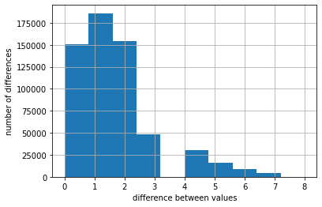

```python
diff = np.abs(result - y_test)
diff_df = pd.DataFrame(data=diff, columns=["difference"])
diff_df['difference'].hist(bins=10)
plt.xlabel('difference between values')
plt.ylabel('number of differences')
plt.show()
```

```python
diff_df.describe()
```

|  | difference |
| --- | --- |
| count | 599005.000000 |
| mean | 1.545495 |
| std | 1.435584 |
| min | 0.000000 |
| 25% | 0.000000 |
| 50% | 1.000000 |
| 75% | 2.000000 |
| max | 8.000000 |

## Using TextBlob sentiment analyzer and Custom Classifier

Next lets try some new stuff. Here we try to do something similar to our previous approach. However, lets try to use TextBlob instead. Interestingly enough, TextBlob actually gives us the ability to use a custom classifer to predict what our sentiment is. Rather than just exclusively looking at positive and negative values.  
HOWEVER, this training and classification process is EXTREMELY SLOW. So just to take a look at this, we'll be minimizing the data to around 10 thousand data points that will be split similarly to how we did previously in distribution for test and training sets.  
The way this analyzer works is that it uses a feature extractor to send our given sets in and then apply a classifier(NaiveBayes) on it. However, for it to start producing prediction values it needs an initial comment/classification.  
Additionally it uses an nltk classifier and wraps around it, making it slower than the sci-kit classifiers.

```python
Xdrop, X, yDrop, y = train_test_split(df[['comment','rating']],df['rating'], test_size=(10000 / df.shape[0]))
X_train_TB, X_test_TB, y_train_TB, y_test_TB = train_test_split(X, y, test_size=.2,random_state=42)
```

```python
X_train_TB
```

|  | comment | rating |
| --- | --- | --- |
| 9566524 | I like economic games, but this one is dry. No... | 3.0 |
| 6937214 | 2016 | 8.0 |
| 2752726 | Pretty solid game. | 6.0 |
| 7934862 | Seems questionably balanced though enjoyable o... | 6.0 |
| 14445803 | Ba Simple and good game, well playable. | 8.0 |
| ... | ... | ... |
| 8914991 | "Yahtzee Catan" | 6.0 |
| 5538758 | This is my pick of the deck building/cycling g... | 8.0 |
| 7503393 | Was one of my grail games for some time, until... | 8.0 |
| 13170113 | Very thematic and enjoyable game. A little lon... | 8.0 |
| 13057960 | Played once. Played incorrectly. Need to play ... | 5.0 |

8000 rows × 2 columns

```python
X_test_TB
```

|  | comment | rating |
| --- | --- | --- |
| 11506322 | Fun, quick, very light. Minor memory elements ... | 7.0 |
| 11655781 | 1 de Héctor. 1 de Marta y Rocío. | 7.0 |
| 15295452 | Too chaotic and cuthroat. Played once and scor... | 2.0 |
| 15203186 | Very fast paced. Enjoyed but not as much as T... | 6.0 |
| 9688002 | This is a fun straightforward game with nice f... | 8.0 |
| ... | ... | ... |
| 691511 | It is hard to compete with one of the fathers ... | 8.0 |
| 11672765 | 4 - 5 | 7.0 |
| 13281316 | Funny fast game about racing, but be careful n... | 6.0 |
| 15334799 | Very good baseball sim and good value for the ... | 8.0 |
| 15807877 | 2015-02-28 : Play with the variant that a play... | 4.0 |

2000 rows × 2 columns

## Formatting the Data for TextBlob

the classifier needs our records stored in this format

```python
train_records = list(X_train_TB.to_records(index=False))
```

Here we can see that this classifier takes a long while to train itself for just 10 thousand records.

```python
%time cl = NaiveBayesClassifier(train_records)
%time initializer = cl.classify('this is a initializer, for classification')
print(initializer)
```

```
Wall time: 1min 55s
Wall time: 4min
8.0
```

```python
test_records = list(X_test_TB.to_records(index=False))
```

```python
results = []
for item in test_records:
    results.append(cl.classify(item[0]))
results_TB = np.array(results)
```

## Looking at the results of this classifier

Taking a look at this classifier we can see that the precision has decreased due to the data size being lower. If we take a closer look we can see that the ratios of the difference between the predicted values and actual values have decreased though showing a slight increase in "accruacy" rather than precision.

```python
print(findAccuracy(y_test_TB, results))
```

```
0.251
```

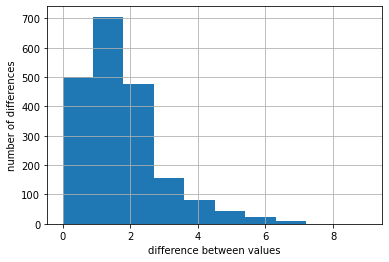

```python
diff_TB = np.abs(results_TB - y_test_TB)
diff_df_TB = pd.DataFrame(data=diff_TB, columns=["difference"])
diff_TB.hist(bins=10)
plt.xlabel('difference between values')
plt.ylabel('number of differences')
plt.show()
```

```python
diff_TB.describe()
```

```
count    2000.000000
mean        1.443500
std         1.348598
min         0.000000
25%         0.000000
50%         1.000000
75%         2.000000
max         9.000000
Name: rating, dtype: float64
```

## Mixing the findings from Vader, TextBlob, and vanilla Sci-kit

```python
X_train, X_test, y_train, y_test = train_test_split(df[['comment','rating']],df['rating'], test_size=0.2)
```

## Taking a look at the results

We can see that the precision and accruacy has increased. Creating a smaller grouping closer to zero.

```python
model = make_pipeline(TfidfVectorizer(), MultinomialNB())
%time model.fit(X_train['comment'], X_train['rating'])
%time results_model = model.predict(X_test['comment'])
print(findAccuracy(y_test, results_model))
```

```
Wall time: 1min 17s
Wall time: 18.8 s
0.305217819550755
```

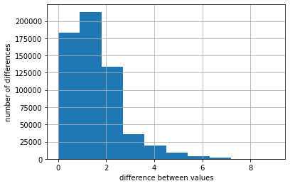

```python
diff = np.abs(results_model - y_test)
diff.hist(bins=10)
plt.xlabel('difference between values')
plt.ylabel('number of differences')
plt.show()
```

```python
diff.describe()
```

```
count    599005.000000
mean          1.242641
std           1.227524
min           0.000000
25%           0.000000
50%           1.000000
75%           2.000000
max           9.000000
Name: rating, dtype: float64
```

## Packaging up best model for our implemented model

```python
filename = 'C:\\Users\\j0sh7\\OneDrive\\Desktop\\Fall 2020\\Data mining\\term proj\\finalized_model.sav'
pickle.dump(model_model, open(filename, 'wb'))
loaded_model = pickle.load(open(filename, 'rb'))
```

```python
%time results_load = loaded_model.predict(X_test['comment'])
print(findAccuracy(y_test, results_load))
```

[output not shown]